# Collection of Visualization

Articles related to producing informative visualization.

# Avoiding Pie Charts

Date: 2016.3.16

The purpose of a pie chart is to show the relationship of parts out of a whole. With that being said they can still be really bad at the one thing they’re ostensibly designed to do. Consider the following pie chart from the [Wall Street Journal](http://www.wsj.com/articles/what-data-scientists-do-all-day-at-work-1457921541) article on What Data Scientists Do All Day at Work.

[figure not shown]

The problem with the plot is that, our original goal was to compare and contrast these six tasks. But at a glance, do you have any idea whether more time is spent on “Presenting Analysis” or “Data Cleaning”? Thus, if the intent was to primarily allow comparison of hours in-task, leaving some ability to compare the same time category across tasks then bar plots are probably the way to go.

Prepares the data `d`, which contains three columns.

- `Task` Different categories of task.
- `Hours` Amounts of time spent.
- `Percentage` Percentage of people that selected this answer.

```r
library(scales)
library(ggplot2)
library(ggthemes)
library(data.table)
setwd("/Users/ethen/Business-Analytics/visualization/avoid_pie_charts")
d <- fread("pie.txt")
d <- melt( d, id.vars = "Task",
           variable.name = "Hours", value.name = "Percentage" )
head(d)
```

```
##                               Task      Hours Percentage
## 1: Basic exploratory data analysis < 1 a week         11
## 2:                   Data cleaning < 1 a week         19
## 3:     Machine learning/statistics < 1 a week         34
## 4:         Creating visualizations < 1 a week         23
## 5:             Presenting analysis < 1 a week         27
## 6:          Extract/transform/load < 1 a week         43
```

## Plots

**Alternative 1: Bar Plot**

Rotates the x axis’s text and label the exact percentages as text right on the graph, which can be useful when you want to pick out a specific number to emphasize on it.

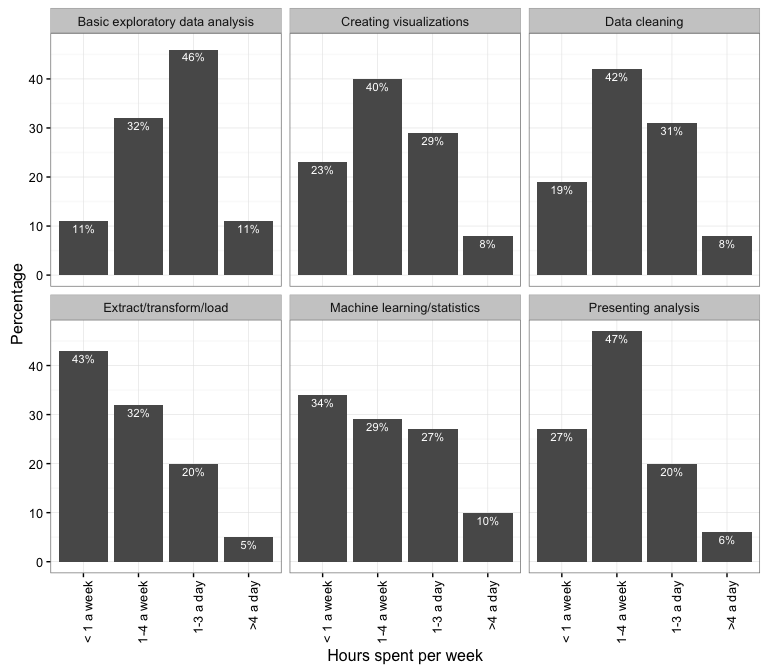

```r
p1 <- ggplot( d, aes( x = Hours, y = Percentage ) ) +
      geom_bar( stat = "identity" ) +
      facet_wrap( ~ Task ) +
      xlab("Hours spent per week") +
      geom_text( aes( label = paste0( Percentage, "%" ), y = Percentage ),
                 vjust = 1.4, size = 3, color = "white" )
p1 + theme_bw() +
theme( axis.text.x = element_text( angle = 90,  hjust = 1 ) )
```

**Alternative 2: Bar Plot**

Using the `theme_tufte` from the `ggthemes` package. The theme will drop all the borders, grids, and axis lines to maximize the data / ink ratio.

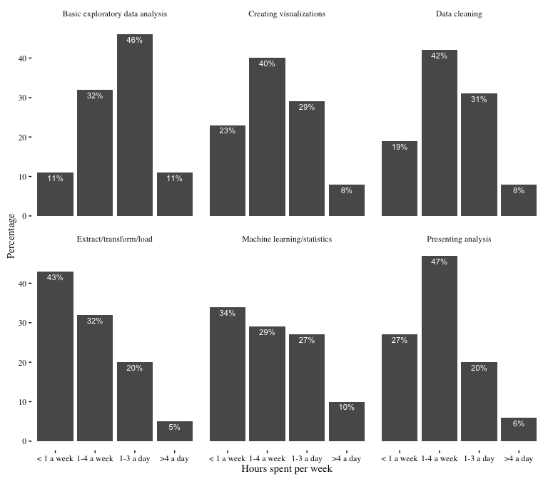

```r
p1 + theme_tufte()
```

**Alternative 3: Stacked Bar Plot**

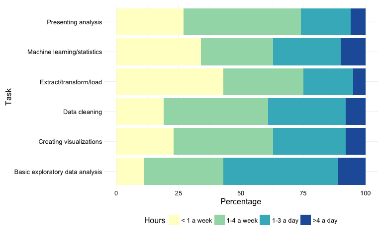

```r
ggplot( d, aes( x = Task, y = Percentage, fill = Hours ) ) +
geom_bar( stat = "identity", position = "stack" ) +
coord_flip() +
scale_fill_brewer( palette = "YlGnBu" ) +
theme_minimal() + theme( legend.position = "bottom" )
```

**Alternative 4: Refined Version of Bar Plot**

Some notes on ggplot2’s grammar.

The amount of time spent on various tasks by surveyed non-managers in data-science positions. ( could be added to the plot as subtitles ). Although this isn’t actually going to tell us which tasks data scientists spend the most time on: we should do some kind of weighted measure to estimate the mean.

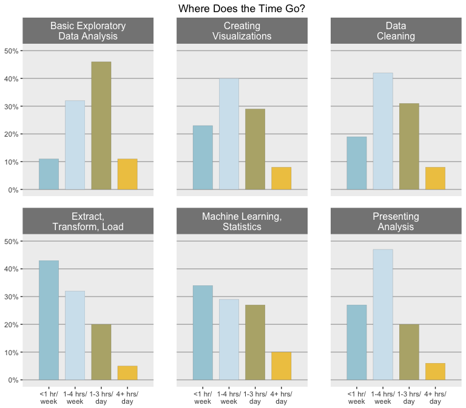

```r
# refined x label and strip label
x_labels <- c( "<1 hr/\nweek", "1-4 hrs/\nweek", "1-3 hrs/\nday", "4+ hrs/\nday" )
label_names <- c( "Basic exploratory data analysis" = "Basic Exploratory\nData Analysis",
                  "Data cleaning" = "Data\nCleaning",
                  "Machine learning/statistics" = "Machine Learning,\nStatistics",
                  "Creating visualizations" = "Creating\nVisualizations",
                  "Presenting analysis" = "Presenting\nAnalysis",
                  "Extract/transform/load" = "Extract,\nTransform, Load" )

ggplot( d, aes( x = Hours, y = Percentage / 100, fill = Hours ) ) +
geom_bar( stat = "identity", width = 0.75, color = "#2b2b2b", size = 0.05 ) +
scale_y_continuous( labels = percent, limits = c( 0, 0.5 ) ) +
scale_x_discrete( expand = c( 0, 1 ), labels = x_labels ) +
scale_fill_manual( values = c( "#a6cdd9", "#d2e4ee", "#b7b079", "#efc750" ) ) +
facet_wrap( ~ Task, labeller = as_labeller(label_names) ) +
labs( x = NULL, y = NULL, title = "Where Does the Time Go?" ) +
theme( strip.text = element_text( size = 12, color = "white", hjust = 0.5 ),
       strip.background = element_rect( fill = "#858585", color = NA ),
       panel.background = element_rect( fill = "#efefef", color = NA ),
       panel.grid.major.x = element_blank(),
       panel.grid.minor.x = element_blank(),
       panel.grid.minor.y = element_blank(),
       panel.grid.major.y = element_line( color = "#b2b2b2" ),
       panel.margin.x = unit( 1, "cm" ),
       panel.margin.y = unit( 0.5, "cm" ),
       legend.position = "none" )
```

**Sources:** source code can be obtained [here](https://github.com/ethen8181/Business-Analytics/blob/master/visualization/avoid_pie_charts/pie.R).

## Reference

1. Worst Chart In The World: http://www.businessinsider.com/pie-charts-are-the-worst-2013-6
2. How to replace a pie chart: http://varianceexplained.org/r/improving-pie-chart/
3. Take the Pies out of Pi Day: http://rud.is/b/2016/03/14/spinning-cycles-in-box-4-to-take-the-pies-out-of-pi-day/

# Next Chart

Ming-Yu Liu

2016-03-16